# QTM302W: EDA on Quarterly Data for Macroeconomic Research

Laura Wang, Sean Jeon, Yuting Chen, Kari Zhou

2025-12-11

# 0. Introduction

This notebook represents the quantitative foundation of our larger research project, “**Resilience and Recovery: Tracing the U.S. Economic Trajectory (2000–2025).**” While our broader project examines the housing activity and policy implications behind the economic shock, this analysis provides the empirical evidence necessary to validate those narratives of how the key economic variables and housing indicators are correlated and fluctuated from 2000 to 2025.

We draw on the **FRED-QD (Federal Reserve Economic Data – Quarterly Data)** dataset, a comprehensive macroeconomic database maintained by the Federal Reserve Bank of St. Louis. This dataset includes U.S. economy data from the Bureau of Economic Analysis (BEA) and the Bureau of Labor Statistics (BLS), including core categories such as output, consumption, investment, government spending, trade, and housing.

Although the dataset covers a long time period since the 1960s, we focused on data from **2000 to 2025**, and using that to examine the long-run economic trends and cyclical fluctuations. This period experienced three distinct economic shocks: the Great Recession, the Trade War, and the COVID-19 pandemic. The purpose of this exploratory analysis is to:

1. **Investigate the evolution of Gross Domestic Product (GDP) and its major components**, emphasizing how domestic activity and external trade dynamics contribute to overall economic performance.
2. **Isolate Housing Indicators** as a leading signal of broader economic health.
3. **Investigate Policy Impacts**, specifically on the relationship between interest rates, government spending and private investment.

The dataset poses minimal ethical concerns as it consists entirely of publicly available, aggregate economic statistics that contain no individual-level or proprietary information. Our analysis therefore centers on responsible interpretation, transparency in data handling, and reproducible economic insights derived from public data. This analysis adheres to reproducible research standards, relying entirely on public, aggregate statistics with no ethical concerns regarding individual privacy.

# 1. Preparing the Foundation: Data Cleaning and Formatting

Before we can interpret economic signals, we must clean the raw FRED-QD dataset since it contains metadata rows that must be stripped out to prevent parsing errors.

In the code chunk: 1. **Loading Data and Removing Rows**: We load the Federal Reserve Economic Quarterly Data file titled 2025-09-QD.csv and remove the transformation code row (row 2) to align the dataset. 2. **Formatting**: Then, we renamed the ‘sasdate’ to ‘date,’ and format the time index to a standard `month-day-year` format. We convert all data columns into numeric types and coercing errors to NA values. 3. **Filtering**: Since we are only interested in data from January 2000 to August 2025, we restrict the sample to the time window of interest and only focus on the modern economic cycle.

```r
data <- read.csv("data/2025-09-QD.csv")
data <- data[-1, ]

names(data)[1] <- "date"
data$date <- as.Date(data$date, "%m/%d/%Y")

data <- data %>%
  mutate(across(-date, ~as.numeric(as.character(.))))

startSample <- as.Date("2000-01-01")
endSample   <- as.Date("2025-08-01")

df <- data %>%
  filter(date >= startSample & date <= endSample)
```

# 2. Snapshot of the Economy: Descriptive Statistics

To ground our analysis, we establish a baseline of central tendencies and volatility by creating a summarization table including key variables for the U.S. economy.

```r
vars_to_summarize <- c("GDPC1", "PCECC96", "GPDIC1", "GCEC1", "HOUST",
                       "MORTGAGE30US", "FEDFUNDS", "UMCSENTx", "USSTHPI", "DPIC96")

get_stats <- function(x) {
  c(
    N = length(x) - sum(is.na(x)), # Count of non-missing values
    Mean = mean(x, na.rm = TRUE),
    StDev = sd(x, na.rm = TRUE),
    Min = min(x, na.rm = TRUE),
    Median = median(x, na.rm = TRUE),
    Max = max(x, na.rm = TRUE)
  )
}

summary_matrix <- sapply(df[vars_to_summarize], get_stats)
summary_table <- t(summary_matrix)

readable_names <- c("GDP", "Consumption", "Investment", "Gov. Spend",
                    "Housing Starts", "Mortgage Rate", "Fed Funds Rate",
                    "Sentiment", "House Price Idx", "Disp. Income")

rownames(summary_table) <- readable_names

knitr::kable(summary_table,
             digits = 2,
             caption = "Descriptive Statistics for Key Variables (2000-2025)")
```

Descriptive Statistics for Key Variables (2000-2025)

|  | N | Mean | StDev | Min | Median | Max |
| --- | --- | --- | --- | --- | --- | --- |
| GDP | 102 | 18159.50 | 2755.27 | 13878.15 | 17479.75 | 23770.98 |
| Consumption | 102 | 12252.71 | 2007.91 | 9039.74 | 11714.71 | 16445.69 |
| Investment | 102 | 3088.39 | 702.72 | 1946.87 | 2877.04 | 4547.95 |
| Gov. Spend | 102 | 3408.44 | 267.28 | 2831.90 | 3380.20 | 4003.78 |
| Housing Starts | 102 | 1307.22 | 424.75 | 525.67 | 1340.17 | 2120.33 |
| Mortgage Rate | 102 | 5.18 | 1.40 | 2.76 | 5.04 | 8.32 |
| Fed Funds Rate | 102 | 1.97 | 2.03 | 0.06 | 1.25 | 6.52 |
| Sentiment | 102 | 82.42 | 13.26 | 55.00 | 83.80 | 110.10 |
| House Price Idx | 102 | 406.65 | 68.03 | 308.81 | 394.72 | 559.53 |
| Disp. Income | 102 | 13531.19 | 2363.85 | 9833.87 | 12988.58 | 18473.31 |

From the descriptive statistics table, we are able to see that the dataset from 2000 to 2025 contains 102 quarterly observations for each variable.

GDP averages 18,159.50 with a standard deviation of 2,755.27, showing steady growth and moderate fluctuation over time. Consumption (mean = 12,252.71) follows a similar trend but with slightly less variation. Investment and government spending average 3,088.39 and 3,408.44, respectively, with spending showing more stability than investment.

Overall, the statistics show that key macroeconomic indicators moved together over the past 25 years, with notable fluctuations in housing and monetary policy variables.

# 3. Decomposing Growth: The Changing Composition of GDP

Gross Domestic Product is more than a single number; it is the sum of consumption, investment, government spending, and net exports (export - import).

In this section, we calculated the proportion each component takes of the total GDP, and visualized them using a line chart to show the trends over time, and a stacked area chart to show the relative weight of each component of GDP. In addition to plotting the components of GDP, we also added three grey dashed line to indicate the time of our interest, 2008 Global Financial Crisis, 2018 Trade War, and the COVID-19 pandemic.

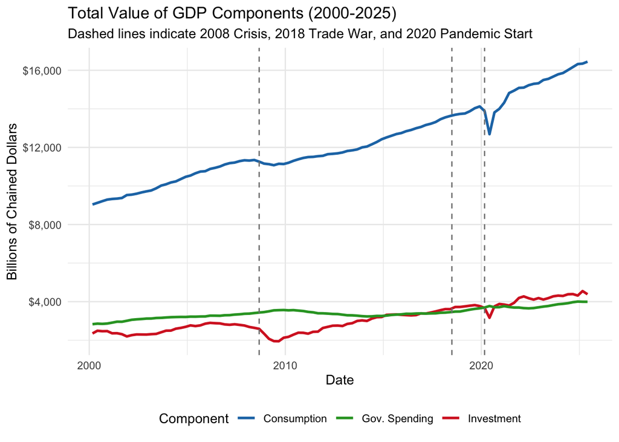

```r
df <- df %>%
  mutate(
    C_proportion = PCECC96 / GDPC1,
    I_proportion = GPDIC1 / GDPC1,
    G_proportion = GCEC1 / GDPC1,
    X_proportion = EXPGSC1 / GDPC1,
    M_proportion = IMPGSC1 / GDPC1,
    NX_proportion = (EXPGSC1 - IMPGSC1) / GDPC1
  )

# Plot 1: Line chart for absolute trend analysis
p_value_line_all <- ggplot(df, aes(x = date)) +
  geom_line(aes(y = PCECC96, color = "Consumption"), size=1) +
  geom_line(aes(y = GPDIC1, color = "Investment"), size=1) +
  geom_line(aes(y = GCEC1, color = "Gov. Spending"), size=1) +
  # Add vertical lines to mark major crises for context
  geom_vline(xintercept = as.Date("2008-09-01"), linetype="dashed", color="gray50") +
  geom_vline(xintercept = as.Date("2018-07-01"), linetype="dashed", color="gray50") +
  geom_vline(xintercept = as.Date("2020-03-01"), linetype="dashed", color="gray50") +
  labs(title = "Total Value of GDP Components (2000-2025)",
       subtitle = "Dashed lines indicate 2008 Crisis, 2018 Trade War, and 2020 Pandemic Start",
       y = "Billions of Chained Dollars", x = "Date") +
  scale_y_continuous(labels = scales::dollar) +
  scale_color_manual(name = "Component", values = c("Consumption" = "#1f77b4",
                                                    "Investment" = "#d62728",
                                                    "Gov. Spending" = "#2ca02c")) +
  theme_minimal() +
  theme(legend.position = "bottom")
p_value_line_all
```

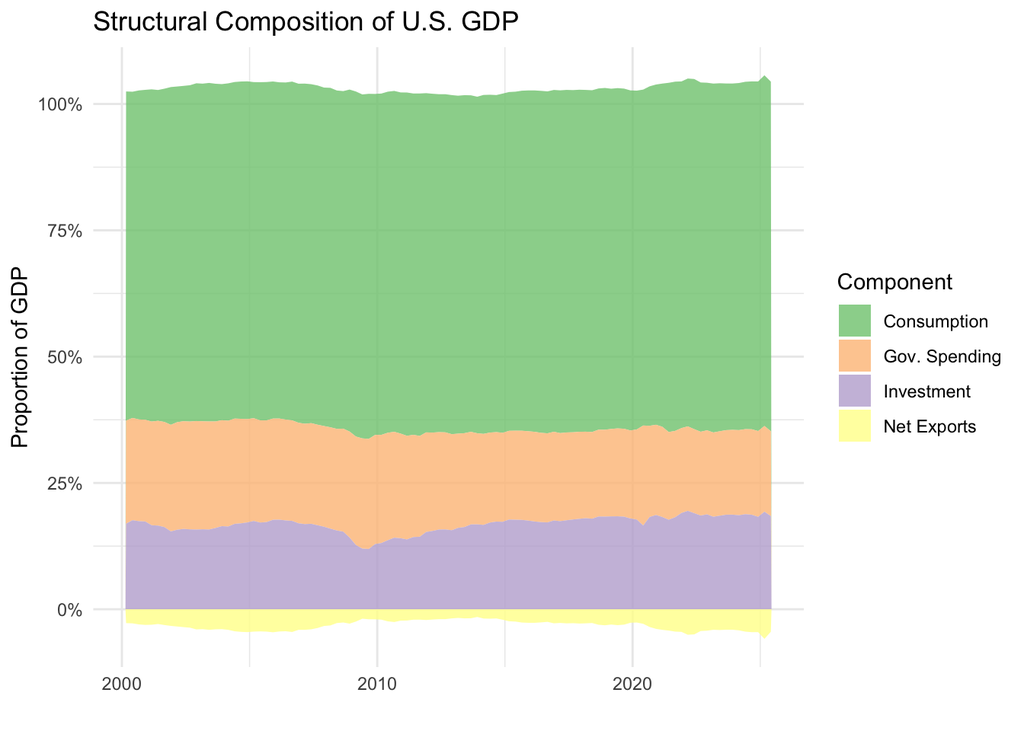

```r
# Plot 2: Stacked area chart for structural composition
p_proportions_area_full <- df %>%
  select(date, C_proportion, I_proportion, G_proportion, NX_proportion) %>%
  pivot_longer(cols = -date, names_to = "component", values_to = "proportion") %>%
  ggplot(aes(x = date, y = proportion, fill = component)) +
  geom_area(alpha=0.8) +
  labs(title = "Structural Composition of U.S. GDP",
       y = "Proportion of GDP", x = "") +
  scale_y_continuous(labels = scales::percent) +
  scale_fill_manual(name = "Component",
                    values = c("C_proportion"="#7fc97f", "I_proportion"="#beaed4",
                               "G_proportion"="#fdc086", "NX_proportion"="#ffff99"),
                    labels = c("Consumption", "Gov. Spending", "Investment", "Net Exports")) +
  theme_minimal()

p_proportions_area_full
```

# 4. Interdependencies: The Correlation Matrix

Variables affects the economy may also have influence on other things, like the mortgage rate, federal funds rate, and even housing starts and the house price index. To get a sense of how these economic variables may impact other variables, we construct a correlation matrix to quantify the strength of linear relationship between our key variables.

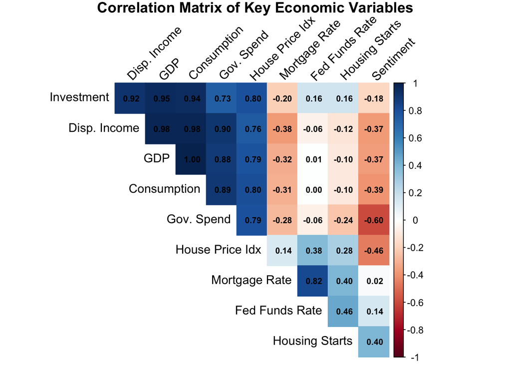

```r
selected_vars <- df %>%
  select(GDPC1, PCECC96, GPDIC1, GCEC1, HOUST, MORTGAGE30US, FEDFUNDS, UMCSENTx, USSTHPI, DPIC96)

readable_names <- c("GDP", "Consumption", "Investment", "Gov. Spend", "Housing Starts",
                    "Mortgage Rate", "Fed Funds Rate", "Sentiment", "House Price Idx", "Disp. Income")

cor_matrix <- cor(selected_vars, use = "pairwise.complete.obs")
colnames(cor_matrix) <- readable_names
rownames(cor_matrix) <- readable_names

# Visualizing the matrix
corrplot(cor_matrix, method = "color",
         type = "upper",
         order = "hclust",
         addCoef.col = "black", tl.col = "black",
         tl.srt = 45, diag = FALSE,
         number.cex = 0.7,
         title = "Correlation Matrix of Key Economic Variables", mar=c(0,0,1,0))
```

The most prominent pattern is the strong positive correlation among GDP, consumption, investment, and disposable income, all with coefficients above 0.9. This confirms that these core components of economic activity tend to rise and fall together, reflecting their shared dependence on overall economic growth. Government spending is also positively correlated with these variables, though slightly less strongly, which makes sense since fiscal policy often responds countercyclically, rising during downturns and moderating during expansions.

# 5. Testing Economic Theory: Trade and Rational Actors

We have looked at the broad trends for the major indicators. Now we need to drill down into specific relationships to see if the data behaves the way economic theory says it should. We want to test three specific stories about the economy. We want to know if trade deficits react to policy changes. We want to see if businesses actually stop investing when interest rates go up. And finally we want to see if consumer feelings actually predict their spending.

**The Trade Gap**

First we look at the balance of trade. The chart below tracks Real Exports in dark blue against Real Imports in orange. We have added shaded regions to mark the 2019 Trade War and the policy adjustments in 2025. We wanted to see if political interventions successfully shrank the gap between what we buy and what we sell.

The data suggests that the deficit is stubborn. While the 2020 shock caused both lines to drop briefly, the gap reasserted itself almost immediately. This suggests that tariff policies have not fundamentally changed the American appetite for foreign goods.

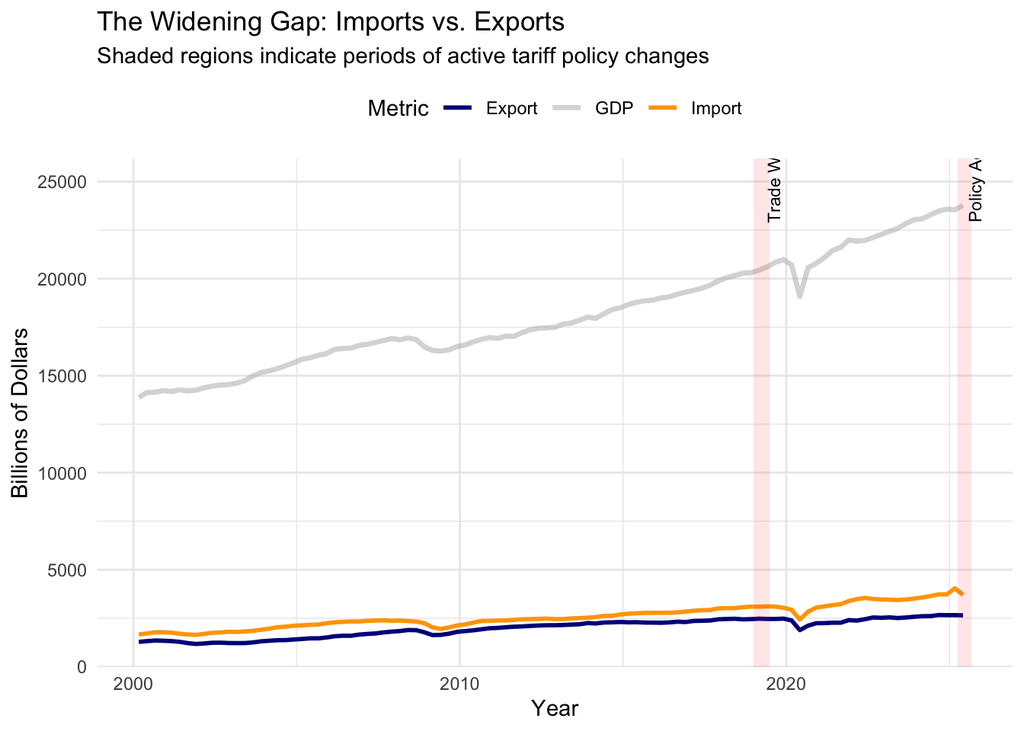

```r
ggplot(data = df, aes(x = date))+
  geom_line(aes( y = EXPGSC1, color = "Export"), size=1)+
  geom_line(aes(y = IMPGSC1, color = "Import"), size=1)+
  geom_line(aes(y = GDPC1, color = "GDP"), size=1.2, alpha=0.5)+
  scale_color_manual(values = c("Export" = "darkblue",
                                "Import" = "orange",
                                "GDP" = "gray70"
                               )) +
  # Highlight Tariff Policy Periods
  annotate("rect", fill = "red", alpha = 0.1,
           xmin = as.Date(c("2019-01-01")), xmax = as.Date(c("2019-06-30")),
           ymin = -Inf, ymax = Inf) +
  annotate("text", x = as.Date("2019-04-01"), y = 25000, label="Trade War", angle=90, vjust=1.5, size=3) +

  annotate("rect", fill = "red", alpha = 0.1,
           xmin = as.Date(c("2025-04-02")), xmax = as.Date(c("2025-09-01")),
           ymin = -Inf, ymax = Inf) +
    annotate("text", x = as.Date("2025-06-01"), y = 25000, label="Policy Adj.", angle=90, vjust=1.5, size=3) +

  labs(color = "Metric",
       title = "The Widening Gap: Imports vs. Exports",
       subtitle = "Shaded regions indicate periods of active tariff policy changes",
       x = "Year",
       y = "Billions of Dollars") +
  theme_minimal() +
  theme(legend.position = "top")
```

**Rational Actors and Investment**

Next we check the textbook definitions of rational behavior. We constructed three scatterplots to visualize these relationships.

The top left plot compares the Federal Funds Rate to Real Investment. Standard theory says high rates should kill investment. Our data shows a cloud with no clear direction. This implies that businesses invest based on long term demand rather than just the immediate cost of borrowing.

The top right plot compares Consumer Sentiment to Real Consumption. We expected a strong positive line. The data is messy here as well. People sometimes say they are pessimistic but they continue to shop anyway.

The bottom plot compares Disposable Income to Consumption. This relationship is crystal clear. The points form a tight diagonal line. This tells us that income is the single best predictor of economic activity. If people have money then they spend it.

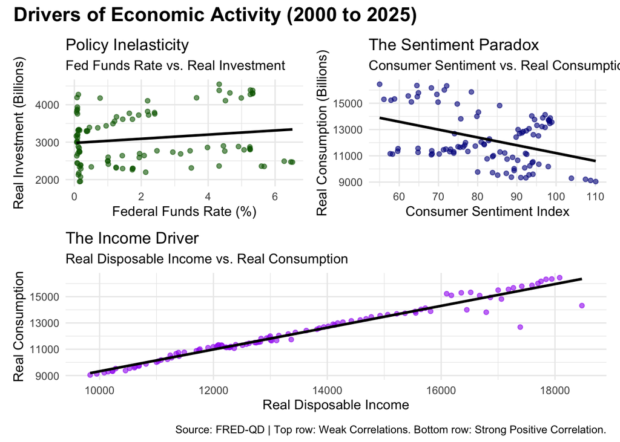

```r
# Plot A: Interest Rates vs Investment
p_scatter_investment <- ggplot(df, aes(x = FEDFUNDS, y = GPDIC1)) +
  geom_point(alpha = 0.6, color = "darkgreen") +
  geom_smooth(method = "lm", se = FALSE, color = "black") +
  labs(title = "Policy Inelasticity",
       subtitle = "Fed Funds Rate vs. Real Investment",
       x = "Federal Funds Rate (%)", y = "Real Investment (Billions)") +
  theme_minimal()

# Plot B: Sentiment vs Consumption
p_scatter_sentiment <- ggplot(df, aes(x = UMCSENTx, y = PCECC96)) +
  geom_point(alpha = 0.6, color = "darkblue") +
  geom_smooth(method = "lm", se = FALSE, color = "black") +
  labs(title = "The Sentiment Paradox",
       subtitle = "Consumer Sentiment vs. Real Consumption",
       x = "Consumer Sentiment Index", y = "Real Consumption (Billions)") +
  theme_minimal()

# Plot C: Income vs Consumption
p_scatter_income <- ggplot(df, aes(x = DPIC96, y = PCECC96)) +
  geom_point(alpha = 0.6, color = "purple") +
  geom_smooth(method = "lm", se = FALSE, color = "black") +
  labs(title = "The Income Driver",
       subtitle = "Real Disposable Income vs. Real Consumption",
       x = "Real Disposable Income", y = "Real Consumption") +
  theme_minimal()

combined_plot <- (p_scatter_investment + p_scatter_sentiment) / p_scatter_income
combined_plot + plot_annotation(
  title = "Drivers of Economic Activity (2000 to 2025)",
  caption = "Source: FRED-QD | Top row: Weak Correlations. Bottom row: Strong Positive Correlation.",
  theme = theme(plot.title = element_text(size = 16, face = "bold"))
)
```

# 6. Housing as a Leading Indicator

Housing is physical and capital intensive. This makes it a great signal for the broader economy. We wanted to see if the recovery in housing was uniform across the country or if specific regions were driving the growth.

**The Regional Split**

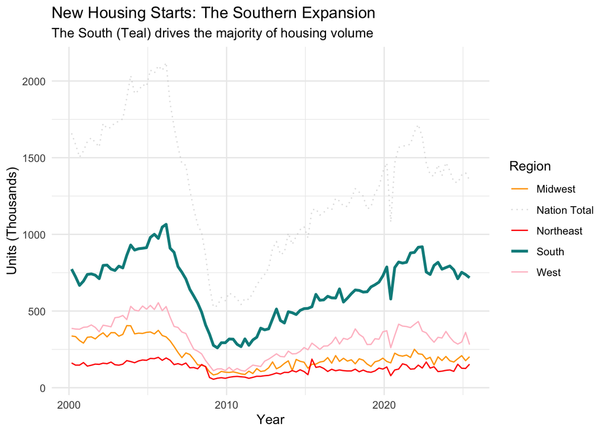

```r
ggplot(data = df, aes(x = date))+
  geom_line(aes(y = HOUST, color = "Nation Total"), linetype="dotted", alpha=0.5) +
  geom_line(aes(y = HOUSTMW, color = "Midwest")) +
  geom_line(aes(y = HOUSTNE, color = "Northeast")) +
  geom_line(aes(y = HOUSTS, color = "South"), size=1.1) + # Emphasize South
  geom_line(aes(y = HOUSTW, color = "West"))+
  scale_color_manual(values = c("Nation Total" = "gray",
                                "Midwest" = "orange",
                                "Northeast" = "red",
                                "South" = "darkcyan", # Highlight color
                                "West" = "pink")) +
  labs(color = "Region",
       title = "New Housing Starts: The Southern Expansion",
       subtitle = "The South (Teal) drives the majority of housing volume",
       x = "Year",
       y = "Units (Thousands)") +
  theme_minimal()
```

**Smoothing the Volatility**

[figure not shown]

```r
df <- df %>%
  mutate(MA_6month = zoo::rollmean(PERMIT, k = 6, fill = NA, align = "right"))

ggplot(df, aes(x = date)) +
  geom_line(aes(y = HOUST, color = "Raw Data (Monthly)"), alpha=0.4) +
  geom_line(aes(y = MA_6month, color = "6 Month Trend"), size = 1.2) +
  labs(title = "Smoothing the Cycle",
       subtitle = "National Housing Starts with 6 Month Moving Average",
       x = "Date", y = "Units (Thousands)") +
  scale_color_manual(values = c("Raw Data (Monthly)" = "gray50", "6 Month Trend" = "blue")) +
  theme_minimal() +
  theme(legend.position = "bottom")
```

**The Fiscal Relationship**

Finally we checked the relationship between Government Spending and Housing Starts. The correlation is negative. This might look like the government is crowding out private builders. The reality is likely different. The government usually spends money on stimulus packages exactly when the private sector is collapsing. The negative correlation is a sign of reactive policy.

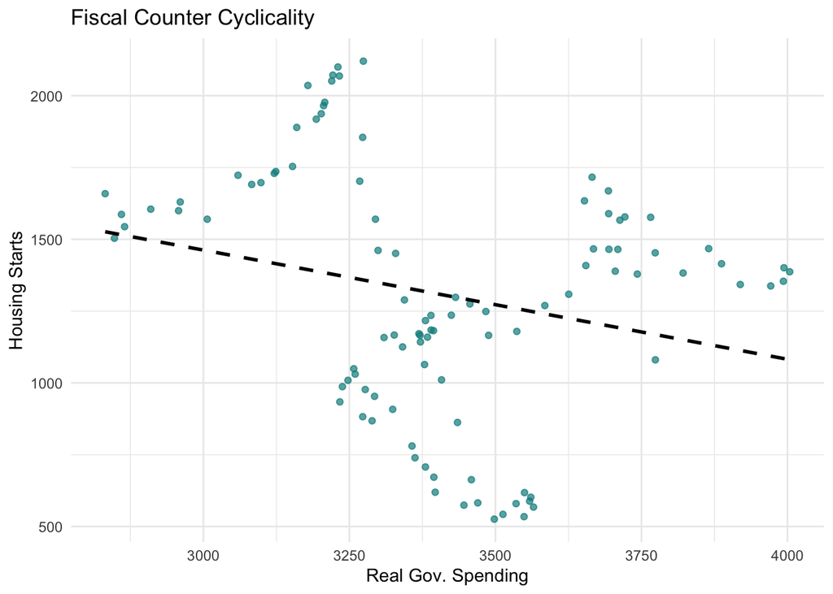

```r
p_scatter_houst_gov <- ggplot(df, aes(x = GCEC1, y = HOUST)) +
  geom_point(alpha = 0.7, color = "darkcyan") +
  geom_smooth(method = "lm", se = FALSE, color = "black", linetype = "dashed") +
  labs(title = "Fiscal Counter Cyclicality",
       x = "Real Gov. Spending", y = "Housing Starts") +
  theme_minimal()

p_scatter_houst_gov
```

# 7. Conclusion

We spent this notebook exploring the contours of the American economy from 2000 to 2025. This process has clarified the structure of our dataset and pointed us toward specific research questions.

**Future Work**

This exploratory analysis showed us what happened. The next step is to understand why. The most confusing finding was the lack of correlation between interest rates and investment. We know rates matter. But the effect is not immediate. Our future work will use Vector Autoregression models to measure the time lag between a rate hike and a drop in investment. This will help us understand the causal timeline of economic recovery.

# 8. Works Cited

Michael W. McCracken and Serena Ng. “FRED-QD: A Quarterly Database for Macroeconomic Research.” Federal Reserve Bank of St. Louis Review, First Quarter 2021. https://doi.org/10.20955/r.103.1-44

Fred-MD and Fred-QD: Monthly and quarterly databases for Macroeconomic Research. Federal Reserve Bank of St. Louis. https://www.stlouisfed.org/research/economists/mccracken/fred-databases